# MM microarray data processing 20220414

```r
library(GEOquery)
library(readr)
library(tidyr)
library(dplyr)
library(ggplot2)
library(stringr)
```

not using

```r
# gse2658 <- getGEO('GSE2658', GSEMatrix=TRUE)
# show(gse2658)
```

## bring in data

geo data from GSE2658 (Shaughnessy data from GEO)  
https://www.ncbi.nlm.nih.gov/geo/query/acc.cgi?acc=GSE2658

```r
gse2658_lc <- getGEO(
  filename="~/Documents/stats/survival/commpass_proj/mm_microarray_datasets/GSE2658_series_matrix.txt.gz",
  GSEMatrix=TRUE)
show(gse2658_lc)
```

```
ExpressionSet (storageMode: lockedEnvironment)
assayData: 54675 features, 559 samples
  element names: exprs
protocolData: none
phenoData
  sampleNames: GSM50986 GSM50987 ... GSM102634 (559 total)
  varLabels: title geo_accession ... data_row_count (52 total)
  varMetadata: labelDescription
featureData
  featureNames: 1007_s_at 1053_at ... AFFX-TrpnX-M_at (54675 total)
  fvarLabels: ID GB_ACC ... Gene Ontology Molecular Function (16 total)
  fvarMetadata: Column Description labelDescription
experimentData: use 'experimentData(object)'
  pubMedIds: 16688228
16728703
17023574
19837979
29980194
30213928
25753926
27363682
23456977
23537707
18337559
33572851
Annotation: GPL570
```

get out phenotype data

```r
gse2658_pdata <- pData(phenoData(gse2658_lc))
gse2658_pdata
```

|  | title | geo_accession | status | submission_date | last_update_date | type | channel_count | source_name_ch1 | organism_ch1 | characteristics_ch1 | characteristics_ch1.1 | characteristics_ch1.2 | characteristics_ch1.3 | characteristics_ch1.4 | characteristics_ch1.5 | characteristics_ch1.6 | characteristics_ch1.7 | characteristics_ch1.8 | characteristics_ch1.9 | characteristics_ch1.10 | characteristics_ch1.11 | molecule_ch1 | extract_protocol_ch1 | label_ch1 | label_protocol_ch1 | taxid_ch1 | hyb_protocol | scan_protocol | description | … |
| --- | --- | --- | --- | --- | --- | --- | --- | --- | --- | --- | --- | --- | --- | --- | --- | --- | --- | --- | --- | --- | --- | --- | --- | --- | --- | --- | --- | --- | --- | --- |
| GSM50986 | U133Plus-P002 (TT2 pre-treatment) | GSM50986 | Public on Jun 01 2006 | May 13 2005 | Apr 01 2010 | RNA | 1 | pre-treatment bone marrow | Homo sapiens | [SURIND=0 (Indicator of disease-related death; integer, 0=alive or death by other cause, 1=disease related death, na=death cause undetermined)] |  | [SURTIM=69.24 (Follow-up time in months from Pre-Treatment baseline; integer)] |  | [PCTCELLS=0%/1%/5%/91%/3% (Percentage of cells with 0 copy/1 copy/2 copies/3 copies/4+ copies; percentage)] |  | [AMPIND=3 copies (Indicator of FISH 1q21 Amplification; string, na=not available)] |  | [Subgrp7=CD1] |  |  |  | total RNA | Total RNA was isolated with RNeasy Mini Kit (Qiagen, Valencia, CA). | biotin | As recommended by manufacturer | 9606 | As recommended by manufacturer | As recommended by manufacturer | Following Ficoll-Hypaque gradient centrifugation, plasma cells obtained from the bone marrow were isolated from the mononuclear cell fraction by immunomagnetic bead selection using a monoclonal mouse … | … |
| GSM50987 | U133Plus-P008 (TT2 pre-treatment) | GSM50987 | Public on Jun 01 2006 | May 13 2005 | Apr 01 2010 | RNA | 1 | pre-treatment bone marrow | Homo sapiens | [SURIND=0 (Indicator of disease-related death; integer, 0=alive or death by other cause, 1=disease related death, na=death cause undetermined)] |  | [SURTIM=66.67 (Follow-up time in months from Pre-Treatment baseline; integer)] |  | [PCTCELLS=0%/0%/100%/0%/0% (Percentage of cells with 0 copy/1 copy/2 copies/3 copies/4+ copies; percentage)] |  | [AMPIND=2 copies (Indicator of FISH 1q21 Amplification; string, na=not available)] |  | [CONTAMIND=1 (Indicator of myeloid cell and normal plasma cell contamination; integer, 0=NO, 1=YES, na=Not Available)] |  | [Subgrp7=MY] |  | total RNA | Total RNA was isolated with RNeasy Mini Kit (Qiagen, Valencia, CA). | biotin | As recommended by manufacturer | 9606 | As recommended by manufacturer | As recommended by manufacturer | Following Ficoll-Hypaque gradient centrifugation, plasma cells obtained from the bone marrow were isolated from the mononuclear cell fraction by immunomagnetic bead selection using a monoclonal mouse … | … |
| GSM50988 | U133Plus-P009 (TT2 pre-treatment) | GSM50988 | Public on Jun 01 2006 | May 13 2005 | Apr 01 2010 | RNA | 1 | pre-treatment bone marrow | Homo sapiens | [SURIND=0 (Indicator of disease-related death; integer, 0=alive or death by other cause, 1=disease related death, na=death cause undetermined)] |  | [SURTIM=66.43 (Follow-up time in months from Pre-Treatment baseline; integer)] |  | [PCTCELLS=0%/0%/100%/0%/0% (Percentage of cells with 0 copy/1 copy/2 copies/3 copies/4+ copies; percentage)] |  | [AMPIND=2 copies (Indicator of FISH 1q21 Amplification; string, na=not available)] |  | [Subgrp7=CD2] |  |  |  | total RNA | Total RNA was isolated with RNeasy Mini Kit (Qiagen, Valencia, CA). | biotin | As recommended by manufacturer | 9606 | As recommended by manufacturer | As recommended by manufacturer | Following Ficoll-Hypaque gradient centrifugation, plasma cells obtained from the bone marrow were isolated from the mononuclear cell fraction by immunomagnetic bead selection using a monoclonal mouse … | … |
| GSM50989 | U133Plus-P010 (TT2 pre-treatment) | GSM50989 | Public on Jun 01 2006 | May 13 2005 | Apr 01 2010 | RNA | 1 | pre-treatment bone marrow | Homo sapiens | [SURIND=0 (Indicator of disease-related death; integer, 0=alive or death by other cause, 1=disease related death, na=death cause undetermined)] |  | [SURTIM=66.5 (Follow-up time in months from Pre-Treatment baseline; integer)] |  | [PCTCELLS=0%/0%/100%/0%/0% (Percentage of cells with 0 copy/1 copy/2 copies/3 copies/4+ copies; percentage)] |  | [AMPIND=2 copies (Indicator of FISH 1q21 Amplification; string, na=not available)] |  | [Subgrp7=MS] |  |  |  | total RNA | Total RNA was isolated with RNeasy Mini Kit (Qiagen, Valencia, CA). | biotin | As recommended by manufacturer | 9606 | As recommended by manufacturer | As recommended by manufacturer | Following Ficoll-Hypaque gradient centrifugation, plasma cells obtained from the bone marrow were isolated from the mononuclear cell fraction by immunomagnetic bead selection using a monoclonal mouse … | … |
| GSM50990 | U133Plus-P015 (TT2 pre-treatment) | GSM50990 | Public on Apr 15 2006 | May 13 2005 | Apr 01 2010 | RNA | 1 | pre-treatment bone marrow | Homo sapiens | [SURIND=1 (Indicator of disease-related death; integer, 0=alive or death by other cause, 1=disease related death, na=death cause undetermined)] |  | [SURTIM=42.67 (Follow-up time in months from Pre-Treatment baseline; integer)] |  | [PCTCELLS=0%/0%/1%/90%/9% (Percentage of cells with 0 copy/1 copy/2 copies/3 copies/4+ copies; percentage)] |  | [AMPIND=3 copies (Indicator of FISH 1q21 Amplification; string, na=not available)] |  | [Subgrp7=MS] |  |  |  | total RNA | Total RNA was isolated with RNeasy Mini Kit (Qiagen, Valencia, CA). | biotin | As recommended by manufacturer | 9606 | As recommended by manufacturer | As recommended by manufacturer | Following Ficoll-Hypaque gradient centrifugation, plasma cells obtained from the bone marrow were isolated from the mononuclear cell fraction by immunomagnetic bead selection using a monoclonal mouse … | … |
| GSM50991 | U133Plus-P016 (TT2 pre-treatment) | GSM50991 | Public on Jun 01 2006 | May 13 2005 | Apr 01 2010 | RNA | 1 | pre-treatment bone marrow | Homo sapiens | [SURIND=0 (Indicator of disease-related death; integer, 0=alive or death by other cause, 1=disease related death, na=death cause undetermined)] |  | [SURTIM=65 (Follow-up time in months from Pre-Treatment baseline; integer)] |  | [PCTCELLS=na/na/na/na/na (Percentage of cells with 0 copy/1 copy/2 copies/3 copies/4+ copies; percentage)] |  | [AMPIND=na (Indicator of FISH 1q21 Amplification; string, na=not available)] |  | [Subgrp7=MF] |  |  |  | total RNA | Total RNA was isolated with RNeasy Mini Kit (Qiagen, Valencia, CA). | biotin | As recommended by manufacturer | 9606 | As recommended by manufacturer | As recommended by manufacturer | Following Ficoll-Hypaque gradient centrifugation, plasma cells obtained from the bone marrow were isolated from the mononuclear cell fraction by immunomagnetic bead selection using a monoclonal mouse … | … |
| GSM50992 | U133Plus-P018 (TT2 pre-treatment) | GSM50992 | Public on Apr 15 2006 | May 13 2005 | Apr 01 2010 | RNA | 1 | pre-treatment bone marrow | Homo sapiens | [SURIND=0 (Indicator of disease-related death; integer, 0=alive or death by other cause, 1=disease related death, na=death cause undetermined)] |  | [SURTIM=65.2 (Follow-up time in months from Pre-Treatment baseline; integer)] |  | [PCTCELLS=0%/0%/97%/3%/0% (Percentage of cells with 0 copy/1 copy/2 copies/3 copies/4+ copies; percentage)] |  | [AMPIND=2 copies (Indicator of FISH 1q21 Amplification; string, na=not available)] |  | [Subgrp7=HY] |  |  |  | total RNA | Total RNA was isolated with RNeasy Mini Kit (Qiagen, Valencia, CA). | biotin | As recommended by manufacturer | 9606 | As recommended by manufacturer | As recommended by manufacturer | Following Ficoll-Hypaque gradient centrifugation, plasma cells obtained from the bone marrow were isolated from the mononuclear cell fraction by immunomagnetic bead selection using a monoclonal mouse … | … |
| GSM50993 | U133Plus-P019 (TT2 pre-treatment) | GSM50993 | Public on Jun 01 2006 | May 13 2005 | Apr 01 2010 | RNA | 1 | pre-treatment bone marrow | Homo sapiens | [SURIND=1 (Indicator of disease-related death; integer, 0=alive or death by other cause, 1=disease related death, na=death cause undetermined)] |  | [SURTIM=38.27 (Follow-up time in months from Pre-Treatment baseline; integer)] |  | [PCTCELLS=0%/0%/92%/8%/0% (Percentage of cells with 0 copy/1 copy/2 copies/3 copies/4+ copies; percentage)] |  | [AMPIND=2 copies (Indicator of FISH 1q21 Amplification; string, na=not available)] |  | [Subgrp7=HY] |  |  |  | total RNA | Total RNA was isolated with RNeasy Mini Kit (Qiagen, Valencia, CA). | biotin | As recommended by manufacturer | 9606 | As recommended by manufacturer | As recommended by manufacturer | Following Ficoll-Hypaque gradient centrifugation, plasma cells obtained from the bone marrow were isolated from the mononuclear cell fraction by immunomagnetic bead selection using a monoclonal mouse … | … |
| GSM50994 | U133Plus-P025 (TT2 pre-treatment) | GSM50994 | Public on Jun 01 2006 | May 13 2005 | Apr 01 2010 | RNA | 1 | pre-treatment bone marrow | Homo sapiens | [SURIND=0 (Indicator of disease-related death; integer, 0=alive or death by other cause, 1=disease related death, na=death cause undetermined)] |  | [SURTIM=64.73 (Follow-up time in months from Pre-Treatment baseline; integer)] |  | [PCTCELLS=0%/0%/100%/0%/0% (Percentage of cells with 0 copy/1 copy/2 copies/3 copies/4+ copies; percentage)] |  | [AMPIND=2 copies (Indicator of FISH 1q21 Amplification; string, na=not available)] |  | [CONTAMIND=1 (Indicator of myeloid cell and normal plasma cell contamination; integer, 0=NO, 1=YES, na=Not Available)] |  | [Subgrp7=MY] |  | total RNA | Total RNA was isolated with RNeasy Mini Kit (Qiagen, Valencia, CA). | biotin | As recommended by manufacturer | 9606 | As recommended by manufacturer | As recommended by manufacturer | Following Ficoll-Hypaque gradient centrifugation, plasma cells obtained from the bone marrow were isolated from the mononuclear cell fraction by immunomagnetic bead selection using a monoclonal mouse … | … |
| GSM50995 | U133Plus-P029 (TT2 pre-treatment) | GSM50995 | Public on Jun 01 2006 | May 13 2005 | Apr 01 2010 | RNA | 1 | pre-treatment bone marrow | Homo sapiens | [SURIND=0 (Indicator of disease-related death; integer, 0=alive or death by other cause, 1=disease related death, na=death cause undetermined)] |  | [SURTIM=64.33 (Follow-up time in months from Pre-Treatment baseline; integer)] |  | [PCTCELLS=0%/0%/100%/0%/0% (Percentage of cells with 0 copy/1 copy/2 copies/3 copies/4+ copies; percentage)] |  | [AMPIND=2 copies (Indicator of FISH 1q21 Amplification; string, na=not available)] |  | [Subgrp7=HY] |  |  |  | total RNA | Total RNA was isolated with RNeasy Mini Kit (Qiagen, Valencia, CA). | biotin | As recommended by manufacturer | 9606 | As recommended by manufacturer | As recommended by manufacturer | Following Ficoll-Hypaque gradient centrifugation, plasma cells obtained from the bone marrow were isolated from the mononuclear cell fraction by immunomagnetic bead selection using a monoclonal mouse … | … |

[output cut: 549 more lines]

get out expression matrix

```r
gse2658_exprs <- exprs(gse2658_lc)
dim(gse2658_exprs)
```

```
[1] 54675   559
```

```r
gse2658_exprs[1:10,1:10]
```

```
          GSM50986 GSM50987 GSM50988 GSM50989 GSM50990 GSM50991 GSM50992 GSM50993 GSM50994 GSM50995
1007_s_at    311.7    527.1    196.3    791.6   1155.0    838.1   1162.0    709.1    431.8   1473.7
1053_at      421.0    468.9    335.6    334.1    571.5    416.7    376.9    376.0    431.9    354.5
117_at       315.7    351.2    277.9    959.6    249.9    662.9    266.8    200.1    364.6    149.2
121_at      3720.2   2371.1   2097.2   4262.2   2171.6   3902.2   3203.3   2690.0   2807.0   2854.0
1255_g_at     25.8     52.1     55.8     34.8     32.4     18.9    125.4     92.6    140.7     72.7
1294_at      924.5   1198.1    771.5   1528.2    438.5    624.8   1551.9   1338.2    754.3   1595.6
1316_at      300.3    246.3    111.8    286.5    281.5    232.3     90.0    160.2    200.8    208.8
1320_at       28.7     25.0     17.0     40.1     12.3     25.5     18.0     17.3     14.7     21.7
1405_i_at    189.8     72.6    277.9     49.9    212.8     76.0     12.7     36.8     48.2     60.6
1431_at      341.7    135.8    159.6    205.5    198.7    177.9    142.6    458.4    227.7    278.1
```

```r
gse2658_exprs <- data.frame(gse2658_exprs) %>% tibble::rownames_to_column(var="probe")
```

there is one row with many NAs

```r
gse2658_exprs[which(rowSums(is.na(gse2658_exprs))>0),]
```

|  | probe | GSM50986 | GSM50987 | GSM50988 | GSM50989 | GSM50990 | GSM50991 | GSM50992 | GSM50993 | GSM50994 | GSM50995 | GSM50996 | GSM50997 | GSM50998 | GSM50999 | GSM51000 | GSM51001 | GSM51002 | GSM51003 | GSM51004 | GSM51005 | GSM51006 | GSM51007 | GSM51008 | GSM51009 | GSM51010 | GSM51011 | GSM51012 | GSM51013 | … |
| --- | --- | --- | --- | --- | --- | --- | --- | --- | --- | --- | --- | --- | --- | --- | --- | --- | --- | --- | --- | --- | --- | --- | --- | --- | --- | --- | --- | --- | --- | --- |
| 14 | 1552256_a_at | 961.4 | 966.9 | 481.6 | 405.3 | 430.6 | 2079 | 181.1 | 779 | 1634.5 | 716.9 | 26.8 | 414.5 | 201.6 | 568.4 | 296.7 | 514.8 | 319.8 | 196.8 | 291.7 | 208.9 | 135.4 | 779.1 | 832 | 374.3 | 595.5 | 1068 | 285.1 | 470.8 | … |

get out feature (gene) data

```r
gse2658_features <- fData(gse2658_lc)
```

```r
dim(gse2658_features)
```

```
[1] 54675    16
```

```r
gse2658_features[1:10,]
```

|  | ID | GB_ACC | SPOT_ID | Species Scientific Name | Annotation Date | Sequence Type | Sequence Source | Target Description | Representative Public ID | Gene Title | Gene Symbol | ENTREZ_GENE_ID | RefSeq Transcript ID | Gene Ontology Biological Process | Gene Ontology Cellular Component | Gene Ontology Molecular Function |
| --- | --- | --- | --- | --- | --- | --- | --- | --- | --- | --- | --- | --- | --- | --- | --- | --- |
| 1007_s_at | 1007_s_at | U48705 |  | Homo sapiens | Oct 6, 2014 | Exemplar sequence | Affymetrix Proprietary Database | U48705 /FEATURE=mRNA /DEFINITION=HSU48705 Human receptor tyrosine kinase DDR gene, complete cds | U48705 | discoidin domain receptor tyrosine kinase 1 /// microRNA 4640 | DDR1 /// MIR4640 | 780 /// 100616237 | NM_001202521 /// NM_001202522 /// NM_001202523 /// NM_001954 /// NM_013993 /// NM_013994 /// NR_039783 /// XM_005249385 /// XM_005249386 /// XM_005249387 /// XM_005249389 /// XM_005272873 /// XM_00527… | 0001558 // regulation of cell growth // inferred from electronic annotation /// 0001952 // regulation of cell-matrix adhesion // inferred from electronic annotation /// 0006468 // protein phosphorylat… | 0005576 // extracellular region // inferred from electronic annotation /// 0005615 // extracellular space // inferred from direct assay /// 0005886 // plasma membrane // traceable author statement ///… | 0000166 // nucleotide binding // inferred from electronic annotation /// 0004672 // protein kinase activity // inferred from electronic annotation /// 0004713 // protein tyrosine kinase activity // in… |
| 1053_at | 1053_at | M87338 |  | Homo sapiens | Oct 6, 2014 | Exemplar sequence | GenBank | M87338 /FEATURE= /DEFINITION=HUMA1SBU Human replication factor C, 40-kDa subunit (A1) mRNA, complete cds | M87338 | replication factor C (activator 1) 2, 40kDa | RFC2 | 5982 | NM_001278791 /// NM_001278792 /// NM_001278793 /// NM_002914 /// NM_181471 /// XM_006716080 | 0000278 // mitotic cell cycle // traceable author statement /// 0000722 // telomere maintenance via recombination // traceable author statement /// 0000723 // telomere maintenance // traceable author … | 0005634 // nucleus // inferred from electronic annotation /// 0005654 // nucleoplasm // traceable author statement /// 0005663 // DNA replication factor C complex // inferred from direct assay | 0000166 // nucleotide binding // inferred from electronic annotation /// 0003677 // DNA binding // inferred from electronic annotation /// 0005515 // protein binding // inferred from physical interact… |
| 117_at | 117_at | X51757 |  | Homo sapiens | Oct 6, 2014 | Exemplar sequence | Affymetrix Proprietary Database | X51757 /FEATURE=cds /DEFINITION=HSP70B Human heat-shock protein HSP70B' gene | X51757 | heat shock 70kDa protein 6 (HSP70B') | HSPA6 | 3310 | NM_002155 | 0000902 // cell morphogenesis // inferred from electronic annotation /// 0006200 // ATP catabolic process // inferred from direct assay /// 0006950 // response to stress // inferred from electronic an… | 0005737 // cytoplasm // inferred from direct assay /// 0005814 // centriole // inferred from direct assay /// 0005829 // cytosol // inferred from direct assay /// 0008180 // COP9 signalosome // inferr… | 0000166 // nucleotide binding // inferred from electronic annotation /// 0005524 // ATP binding // inferred from electronic annotation /// 0019899 // enzyme binding // inferred from physical interacti… |
| 121_at | 121_at | X69699 |  | Homo sapiens | Oct 6, 2014 | Exemplar sequence | GenBank | X69699 /FEATURE= /DEFINITION=HSPAX8A H.sapiens Pax8 mRNA | X69699 | paired box 8 | PAX8 | 7849 | NM_003466 /// NM_013951 /// NM_013952 /// NM_013953 /// NM_013992 | 0001655 // urogenital system development // inferred from sequence or structural similarity /// 0001656 // metanephros development // inferred from electronic annotation /// 0001658 // branching invol… | 0005634 // nucleus // inferred from direct assay /// 0005654 // nucleoplasm // inferred from sequence or structural similarity /// 0005730 // nucleolus // inferred from direct assay | 0000979 // RNA polymerase II core promoter sequence-specific DNA binding // inferred from direct assay /// 0003677 // DNA binding // inferred from direct assay /// 0003677 // DNA binding // inferred f… |
| 1255_g_at | 1255_g_at | L36861 |  | Homo sapiens | Oct 6, 2014 | Exemplar sequence | Affymetrix Proprietary Database | L36861 /FEATURE=expanded_cds /DEFINITION=HUMGCAPB Homo sapiens guanylate cyclase activating protein (GCAP) gene exons 1-4, complete cds | L36861 | guanylate cyclase activator 1A (retina) | GUCA1A | 2978 | NM_000409 /// XM_006715073 | 0007165 // signal transduction // non-traceable author statement /// 0007601 // visual perception // inferred from electronic annotation /// 0007602 // phototransduction // inferred from electronic an… | 0001750 // photoreceptor outer segment // inferred from electronic annotation /// 0001917 // photoreceptor inner segment // inferred from electronic annotation /// 0005578 // proteinaceous extracellul… | 0005509 // calcium ion binding // inferred from electronic annotation /// 0008048 // calcium sensitive guanylate cyclase activator activity // inferred from electronic annotation /// 0030249 // guanyl… |
| 1294_at | 1294_at | L13852 |  | Homo sapiens | Oct 6, 2014 | Exemplar sequence | GenBank | L13852 /FEATURE= /DEFINITION=HUME1URP Homo sapiens ubiquitin-activating enzyme E1 related protein mRNA, complete cds | L13852 | microRNA 5193 /// ubiquitin-like modifier activating enzyme 7 | MIR5193 /// UBA7 | 7318 /// 100847079 | NM_003335 /// NR_049825 /// XM_005265430 /// XM_006713321 | 0006464 // cellular protein modification process // inferred from direct assay /// 0016567 // protein ubiquitination // not recorded /// 0016567 // protein ubiquitination // inferred from electronic a… | 0005634 // nucleus // not recorded /// 0005829 // cytosol // not recorded /// 0005829 // cytosol // traceable author statement | 0000166 // nucleotide binding // inferred from electronic annotation /// 0003824 // catalytic activity // inferred from electronic annotation /// 0004839 // ubiquitin activating enzyme activity // not… |
| 1316_at | 1316_at | X55005 |  | Homo sapiens | Oct 6, 2014 | Exemplar sequence | Affymetrix Proprietary Database | X55005 /FEATURE=mRNA /DEFINITION=HSCERBAR Homo sapiens mRNA for thyroid hormone receptor alpha 1 THRA1, (c-erbA-1 gene) | X55005 | thyroid hormone receptor, alpha | THRA | 7067 | NM_001190918 /// NM_001190919 /// NM_003250 /// NM_199334 | 0000122 // negative regulation of transcription from RNA polymerase II promoter // inferred from direct assay /// 0000122 // negative regulation of transcription from RNA polymerase II promoter // inf… | 0000790 // nuclear chromatin // inferred from direct assay /// 0005634 // nucleus // inferred from direct assay /// 0005654 // nucleoplasm // traceable author statement /// 0005737 // cytoplasm // inf… | 0000978 // RNA polymerase II core promoter proximal region sequence-specific DNA binding // inferred from mutant phenotype /// 0001046 // core promoter sequence-specific DNA binding // inferred from d… |
| 1320_at | 1320_at | X79510 |  | Homo sapiens | Oct 6, 2014 | Exemplar sequence | Affymetrix Proprietary Database | X79510 /FEATURE=cds /DEFINITION=HSPTPD1 H.sapiens mRNA for protein-tyrosine-phosphatase D1 | X79510 | protein tyrosine phosphatase, non-receptor type 21 | PTPN21 | 11099 | NM_007039 /// XM_005267287 /// XM_006720011 | 0006470 // protein dephosphorylation // traceable author statement /// 0016311 // dephosphorylation // inferred from electronic annotation /// 0035335 // peptidyl-tyrosine dephosphorylation // inferre… | 0005737 // cytoplasm // inferred from electronic annotation /// 0005856 // cytoskeleton // inferred from electronic annotation | 0004721 // phosphoprotein phosphatase activity // inferred from electronic annotation /// 0004725 // protein tyrosine phosphatase activity // inferred from electronic annotation /// 0005515 // protein… |
| 1405_i_at | 1405_i_at | M21121 |  | Homo sapiens | Oct 6, 2014 | Exemplar sequence | GenBank | M21121 /FEATURE= /DEFINITION=HUMTCSM Human T cell-specific protein (RANTES) mRNA, complete cds | M21121 | chemokine (C-C motif) ligand 5 | CCL5 | 6352 | NM_001278736 /// NM_002985 | 0000165 // MAPK cascade // inferred from mutant phenotype /// 0002407 // dendritic cell chemotaxis // traceable author statement /// 0002548 // monocyte chemotaxis // inferred by curator /// 0002676 /… | 0005576 // extracellular region // traceable author statement /// 0005615 // extracellular space // inferred from electronic annotation /// 0005737 // cytoplasm // inferred from electronic annotation | 0004435 // phosphatidylinositol phospholipase C activity // inferred from direct assay /// 0004672 // protein kinase activity // inferred from direct assay /// 0005125 // cytokine activity // inferred… |
| 1431_at | 1431_at | J02843 |  | Homo sapiens | Oct 6, 2014 | Exemplar sequence | Affymetrix Proprietary Database | J02843 /FEATURE=cds /DEFINITION=HUMCYPIIE Human cytochrome P450IIE1 (ethanol-inducible) gene, complete cds | J02843 | cytochrome P450, family 2, subfamily E, polypeptide 1 | CYP2E1 | 1571 | NM_000773 | 0006641 // triglyceride metabolic process // inferred from electronic annotation /// 0006805 // xenobiotic metabolic process // traceable author statement /// 0008202 // steroid metabolic process // i… | 0000139 // Golgi membrane // inferred from electronic annotation /// 0005739 // mitochondrion // inferred from electronic annotation /// 0005783 // endoplasmic reticulum // inferred from electronic an… | 0004497 // monooxygenase activity // inferred from direct assay /// 0005506 // iron ion binding // inferred from electronic annotation /// 0009055 // electron carrier activity // inferred from electro… |

there are several gene identifiers for each probe, unfortunately none are ensembl ID  
and none other than the probe ID (col==`ID`) are unique…

```r
length(unique(gse2658_features$ID))
```

```
[1] 54675
```

these are gene ID/names below…

genbank accession

```r
length(unique(gse2658_features$GB_ACC))
```

```
[1] 51277
```

```r
length(unique(gse2658_features$`Representative Public ID`))
```

```
[1] 51338
```

this one is the most name like…

```r
length(unique(gse2658_features$`Gene Symbol`))
```

```
[1] 23521
```

```r
gse2658_features %>% group_by(`Gene Symbol`) %>% summarise(n=n()) %>% arrange(desc(n))
```

| Gene Symbol | n |
| --- | --- |
|  | 8893 |
| HFE | 15 |
| ARHGEF12 | 13 |
| CD44 | 13 |
| CSNK1A1 | 13 |
| DNAH1 | 13 |
| LOC100506403 /// LOC101928269 /// RUNX1 | 13 |
| TCF3 | 13 |
| CFLAR | 12 |
| GNAS | 12 |

[output cut: 990 more lines]

```r
gse2658_features %>% group_by(`Gene Symbol`) %>% summarise(n=n()) %>% summarise(sum(n>1))
```

| sum(n > 1) |
| --- |
| 11272 |

```r
length(unique(gse2658_features$ENTREZ_GENE_ID))
```

```
[1] 21880
```

```r
length(unique(gse2658_features$`RefSeq Transcript ID`))
```

```
[1] 21607
```

for reference, this is the gene metadata from the commpass spectra derivation

```r
#"commpass_gene_metadata_20210601.csv"
```

CoMMpass rotation matrix

```r
cmps_spec_rm <-
  read_csv("~/Documents/stats/survival/commpass_proj/spectra_commpass_product/CoMMpass_inclfollowup_final_SpectraData_20210601/spectra_rotation_matrix-gene_centers-2021-06-01.csv.gz")
```

bring in gene annotation to get gene names

```r
gencode_annot <-
  read_csv("~/Documents/stats/survival/commpass_proj/commpass_spectra/Homo_sapiens.GRCh37.74.gtf.flat.csv")
```

```r
gid_names <- gencode_annot %>% distinct(gene_id, .keep_all = T) %>% select(gene_id, gene_name)
```

```r
cmps_spec_rm_wn <- left_join(cmps_spec_rm, gid_names, by="gene_id") %>%
  select(-mean) %>%
  relocate(gene_name)
```

are there any duplicate gene_names?

```r
cmps_spec_rm_wn %>%
    add_count(gene_name) %>%
    filter(n>1) %>%
  select(gene_name, gene_id, n)
```

| gene_name | gene_id | n |
| --- | --- | --- |
| PAGR1 | ENSG00000185928 | 2 |
| PAGR1 | ENSG00000263136 | 2 |

crap, yes there is one, these were apparently combined later. just going to leave them and see how it goes… (note from future Brian, poorly)

```r
dim(cmps_spec_rm_wn)
```

```
[1] 7449   41
```

## combining datasets by gene name

```r
cmps_spec_genenames <- cmps_spec_rm_wn %>% distinct(gene_name) %>% pull(gene_name)
```

```r
gse2658_features %>% filter(`Gene Symbol` %in% cmps_spec_genenames) %>% distinct(`Gene Symbol`) %>% dim()
```

```
[1] 7193    1
```

7193 of 7449 genes in list with simple search (actually there are only 7448 unique gene names)

how many have multiple probe sets?

```r
gse2658_features %>%
  filter(`Gene Symbol` %in% cmps_spec_genenames) %>%
  group_by(`Gene Symbol`) %>%
  summarise(n=n()) %>%
  arrange(desc(n))
```

| Gene Symbol | n |
| --- | --- |
| ARHGEF12 | 13 |
| DNAH1 | 13 |
| TCF3 | 13 |
| SPTBN1 | 11 |
| HIPK2 | 10 |
| KMT2A | 10 |
| MED28 | 10 |
| PDLIM5 | 10 |
| PML | 10 |
| STRN | 10 |

[output cut: 990 more lines]

```r
gse2658_features %>%
  filter(`Gene Symbol` %in% cmps_spec_genenames) %>%
  group_by(`Gene Symbol`) %>%
  summarise(n=n()) %>%
  summarise(sum(n>1))
```

| sum(n > 1) |
| --- |
| 4966 |

4966 out of 7193 have multiple probesets

which genes that are in the spectra rotation matrix are not in the expression set?

```r
cmps_spec_rm_wn %>% distinct(gene_name) %>% filter(!gene_name %in% unique(gse2658_features$`Gene Symbol`))
```

| gene_name |
| --- |
| ST7 |
| ZNF263 |
| JHDM1D |
| RTEL1-TNFRSF6B |
| MAP2K3 |
| FAM136A |
| PHF15 |
| ZC3H11A |
| DNAJC25 |
| MEF2BNB-MEF2B |

[output cut: 245 more lines]

255 genes that are in the spectra rotation matrix are not in the microarray expression data

although there are some genes with double names like `"DDR1 /// MIR4640"`

need to sort out genes that are buried in there with weird names…

## fishing through multiple names

test runs

```r
MAP2K3_sm <- gse2658_features %>%
  filter(grepl("MAP2K3", `Gene Symbol`)) %>%
  select(`Gene Symbol`:`RefSeq Transcript ID`, GB_ACC, `Representative Public ID`)
MAP2K3_sm
```

|  | Gene Symbol | ENTREZ_GENE_ID | RefSeq Transcript ID | GB_ACC | Representative Public ID |
| --- | --- | --- | --- | --- | --- |
| 207667_s_at | LOC100996792 /// MAP2K3 | 5606 /// 100996792 | NM_002756 /// NM_145109 /// NM_145110 /// XM_003846747 /// XM_005256721 /// XM_005256722 /// XM_005256723 /// XR_429863 /// XR_429864 | NM_002756 | NM_002756 |
| 215498_s_at | LOC100996792 /// MAP2K3 | 5606 /// 100996792 | NM_002756 /// NM_145109 /// NM_145110 /// XM_003846747 /// XM_005256721 /// XM_005256722 /// XM_005256723 /// XR_429863 /// XR_429864 | AA780381 | AA780381 |
| 215499_at | LOC100996792 /// MAP2K3 | 5606 /// 100996792 | NM_002756 /// NM_145109 /// NM_145110 /// XM_003846747 /// XM_005256721 /// XM_005256722 /// XM_005256723 /// XR_429863 /// XR_429864 | AA780381 | AA780381 |

```r
MAP2K3_sm %>% filter(grepl("(\\sMAP2K3)|(MAP2K3\\s)",`Gene Symbol`))
```

|  | Gene Symbol | ENTREZ_GENE_ID | RefSeq Transcript ID | GB_ACC | Representative Public ID |
| --- | --- | --- | --- | --- | --- |
| 207667_s_at | LOC100996792 /// MAP2K3 | 5606 /// 100996792 | NM_002756 /// NM_145109 /// NM_145110 /// XM_003846747 /// XM_005256721 /// XM_005256722 /// XM_005256723 /// XR_429863 /// XR_429864 | NM_002756 | NM_002756 |
| 215498_s_at | LOC100996792 /// MAP2K3 | 5606 /// 100996792 | NM_002756 /// NM_145109 /// NM_145110 /// XM_003846747 /// XM_005256721 /// XM_005256722 /// XM_005256723 /// XR_429863 /// XR_429864 | AA780381 | AA780381 |
| 215499_at | LOC100996792 /// MAP2K3 | 5606 /// 100996792 | NM_002756 /// NM_145109 /// NM_145110 /// XM_003846747 /// XM_005256721 /// XM_005256722 /// XM_005256723 /// XR_429863 /// XR_429864 | AA780381 | AA780381 |

```r
ZNF263_sm <- gse2658_features %>%
  filter(grepl("ZNF263", `Gene Symbol`)) %>%
  select(`Gene Symbol`:`RefSeq Transcript ID`, GB_ACC, `Representative Public ID`)
ZNF263_sm
```

|  | Gene Symbol | ENTREZ_GENE_ID | RefSeq Transcript ID | GB_ACC | Representative Public ID |
| --- | --- | --- | --- | --- | --- |
| 203707_at | LINC00921 /// ZNF263 | 10127 /// 283876 | NM_005741 /// NR_033904 /// XM_005255031 /// XM_006720831 /// XM_006720832 /// XM_006720833 /// XM_006720834 /// XM_006720835 | NM_005741 | NM_005741 |
| 232089_at | LINC00921 /// TIGD7 /// ZNF263 | 10127 /// 91151 /// 283876 | NM_005741 /// NM_033208 /// NR_033904 /// XM_005255031 /// XM_006720831 /// XM_006720832 /// XM_006720833 /// XM_006720834 /// XM_006720835 | AI765123 | AI765123 |
| 243547_at | LINC00921 /// ZNF263 | 10127 /// 283876 | NM_005741 /// NR_033904 /// XM_005255031 /// XM_006720831 /// XM_006720832 /// XM_006720833 /// XM_006720834 /// XM_006720835 | BE176531 | BE176531 |

```r
ZNF263_sm %>% filter(grepl("(\\sZNF263)|(ZNF263\\s)",`Gene Symbol`))
```

|  | Gene Symbol | ENTREZ_GENE_ID | RefSeq Transcript ID | GB_ACC | Representative Public ID |
| --- | --- | --- | --- | --- | --- |
| 203707_at | LINC00921 /// ZNF263 | 10127 /// 283876 | NM_005741 /// NR_033904 /// XM_005255031 /// XM_006720831 /// XM_006720832 /// XM_006720833 /// XM_006720834 /// XM_006720835 | NM_005741 | NM_005741 |
| 232089_at | LINC00921 /// TIGD7 /// ZNF263 | 10127 /// 91151 /// 283876 | NM_005741 /// NM_033208 /// NR_033904 /// XM_005255031 /// XM_006720831 /// XM_006720832 /// XM_006720833 /// XM_006720834 /// XM_006720835 | AI765123 | AI765123 |
| 243547_at | LINC00921 /// ZNF263 | 10127 /// 283876 | NM_005741 /// NR_033904 /// XM_005255031 /// XM_006720831 /// XM_006720832 /// XM_006720833 /// XM_006720834 /// XM_006720835 | BE176531 | BE176531 |

```r
JHDM1D_sm <- gse2658_features %>%
  filter(grepl("JHDM1D", `Gene Symbol`)) %>%
  select(`Gene Symbol`:`RefSeq Transcript ID`, GB_ACC, `Representative Public ID`)
JHDM1D_sm
```

|  | Gene Symbol | ENTREZ_GENE_ID | RefSeq Transcript ID | GB_ACC | Representative Public ID |
| --- | --- | --- | --- | --- | --- |
| 232579_at | JHDM1D-AS1 | 100134229 | NR_024451 | AK026372 | AK026372 |

```r
JHDM1D_sm %>% filter(grepl("(\\sJHDM1D)|(JHDM1D\\s)",`Gene Symbol`))
```

| Gene Symbol | ENTREZ_GENE_ID | RefSeq Transcript ID | GB_ACC | Representative Public ID |
| --- | --- | --- | --- | --- |

```r
RTEL1_TNFRSF6B_sm <- gse2658_features %>%
  filter(grepl("RTEL1-TNFRSF6B", `Gene Symbol`)) %>%
  select(`Gene Symbol`:`RefSeq Transcript ID`, GB_ACC, `Representative Public ID`)
RTEL1_TNFRSF6B_sm
```

|  | Gene Symbol | ENTREZ_GENE_ID | RefSeq Transcript ID | GB_ACC | Representative Public ID |
| --- | --- | --- | --- | --- | --- |
| 206467_x_at | RTEL1-TNFRSF6B /// TNFRSF6B | 8771 /// 100533107 | NM_003823 /// NM_032945 /// NR_037882 | NM_003823 | NM_003823 |
| 211526_s_at | RTEL1 /// RTEL1-TNFRSF6B | 51750 /// 100533107 | NM_001283009 /// NM_001283010 /// NM_016434 /// NM_032957 /// NR_037882 | BC000673 | BC000673 |
| 216325_x_at | RTEL1 /// RTEL1-TNFRSF6B | 51750 /// 100533107 | NM_001283009 /// NM_001283010 /// NM_016434 /// NM_032957 /// NR_037882 | AF217796 | AF217796 |

```r
RTEL1_TNFRSF6B_sm %>% filter(grepl("(\\sRTEL1-TNFRSF6B)|(RTEL1-TNFRSF6B\\s)",`Gene Symbol`))
```

|  | Gene Symbol | ENTREZ_GENE_ID | RefSeq Transcript ID | GB_ACC | Representative Public ID |
| --- | --- | --- | --- | --- | --- |
| 206467_x_at | RTEL1-TNFRSF6B /// TNFRSF6B | 8771 /// 100533107 | NM_003823 /// NM_032945 /// NR_037882 | NM_003823 | NM_003823 |
| 211526_s_at | RTEL1 /// RTEL1-TNFRSF6B | 51750 /// 100533107 | NM_001283009 /// NM_001283010 /// NM_016434 /// NM_032957 /// NR_037882 | BC000673 | BC000673 |
| 216325_x_at | RTEL1 /// RTEL1-TNFRSF6B | 51750 /// 100533107 | NM_001283009 /// NM_001283010 /// NM_016434 /// NM_032957 /// NR_037882 | AF217796 | AF217796 |

```r
ST7_sm <- gse2658_features %>%
  filter(grepl("ST7", `Gene Symbol`)) %>%
  select(`Gene Symbol`:`RefSeq Transcript ID`, GB_ACC, `Representative Public ID`)
ST7_sm
```

|  | Gene Symbol | ENTREZ_GENE_ID | RefSeq Transcript ID | GB_ACC | Representative Public ID |
| --- | --- | --- | --- | --- | --- |
| 1552738_a_at | ST7L | 54879 | NM_017744 /// NM_138727 /// NM_138728 /// NM_138729 /// NM_198327 /// NM_198328 /// XM_005270963 /// XM_005270964 /// XM_005270966 /// XM_005270970 /// XM_006710708 /// XM_006710709 /// XR_246280 | NM_138729 | NM_138729 |
| 1552739_s_at | ST7L | 54879 | NM_017744 /// NM_138727 /// NM_138728 /// NM_138729 /// NM_198327 /// NM_198328 /// XM_005270963 /// XM_005270964 /// XM_005270966 /// XM_005270970 /// XM_006710708 /// XM_006710709 /// XR_246280 | NM_138729 | NM_138729 |
| 1555912_at | ST7-AS1 | 93653 | NR_002330 | AI016213 | AI016213 |
| 1559208_at | ST7-OT4 | 338069 | NR_002329 | AA969986 | AA969986 |
| 1564790_at | ST7-AS2 | 93654 | NR_002331 /// NR_109980 /// NR_109981 | AF400045 | AF400045 |
| 206756_at | CHST7 | 56548 | NM_019886 | NM_019886 | NM_019886 |
| 207524_at | MIR6132 /// ST7 /// ST7-OT3 | 7982 /// 93655 /// 102466616 | NM_018412 /// NM_021908 /// NR_002332 /// NR_106748 | NM_021908 | NM_021908 |
| 207871_s_at | MIR6132 /// ST7 /// ST7-OT3 | 7982 /// 93655 /// 102466616 | NM_018412 /// NM_021908 /// NR_002332 /// NR_106748 | NM_018412 | NM_018412 |
| 210140_at | CST7 | 8530 | NM_003650 | AF031824 | AF031824 |
| 219964_at | ST7L | 54879 | NM_017744 /// NM_138727 /// NM_138728 /// NM_138729 /// NM_198327 /// NM_198328 /// XM_005270963 /// XM_005270964 /// XM_005270966 /// XM_005270970 /// XM_006710708 /// XM_006710709 /// XR_246280 | NM_017744 | NM_017744 |

[output cut: 3 more lines]

```r
ST7_sm %>% filter(grepl("(\\sST7)|(ST7\\s)",`Gene Symbol`))
```

|  | Gene Symbol | ENTREZ_GENE_ID | RefSeq Transcript ID | GB_ACC | Representative Public ID |
| --- | --- | --- | --- | --- | --- |
| 207524_at | MIR6132 /// ST7 /// ST7-OT3 | 7982 /// 93655 /// 102466616 | NM_018412 /// NM_021908 /// NR_002332 /// NR_106748 | NM_021908 | NM_021908 |
| 207871_s_at | MIR6132 /// ST7 /// ST7-OT3 | 7982 /// 93655 /// 102466616 | NM_018412 /// NM_021908 /// NR_002332 /// NR_106748 | NM_018412 | NM_018412 |

will need to extract the “simple” (or RNAseq matching) name out of the multiples  
example with a complicated one…  
just looking for space before or after as above with `grepl` seems to work.

```r
str_match(ST7_sm %>% filter(grepl("(\\sST7)|(ST7\\s)",`Gene Symbol`)) %>% pull(`Gene Symbol`),
          pattern="(\\sST7)|(ST7\\s)")[,2] %>% str_trim()
```

```
[1] "ST7" "ST7"
```

fix all names… need list of genes that are in the spectra rotation matrix but not in the expression set

```r
miss_genes <- cmps_spec_rm_wn %>%
  distinct(gene_name) %>%
  filter(!gene_name %in% unique(gse2658_features$`Gene Symbol`)) %>%
  pull(gene_name)
```

subset of `gse2658_features` that have multiple names

```r
genes2fix <- gse2658_features %>%
  filter(grepl("///", `Gene Symbol`)) %>%
  select(ID, `Gene Symbol`)
genes2fix
```

|  | ID | Gene Symbol |
| --- | --- | --- |
| 1007_s_at | 1007_s_at | DDR1 /// MIR4640 |
| 1294_at | 1294_at | MIR5193 /// UBA7 |
| 1552258_at | 1552258_at | LINC00152 /// LOC101930489 |
| 1552283_s_at | 1552283_s_at | ZDHHC11 /// ZDHHC11B |
| 1552388_at | 1552388_at | FLJ30901 /// SCUBE1 |
| 1552401_a_at | 1552401_a_at | BACH1 /// GRIK1-AS2 |
| 1552411_at | 1552411_at | DEFB106A /// DEFB106B |
| 1552412_a_at | 1552412_a_at | DEFB106A /// DEFB106B |
| 1552436_a_at | 1552436_a_at | CDH23 /// LOC100653137 |
| 1552449_a_at | 1552449_a_at | LOC653486 /// SCGB1C1 |

[output cut: 990 more lines]

grabbing genes missing from microarray set so far that have names hidden in the multiple name structure

```r
probe_name <- list() #vector(mode="character")
for(i in seq(1, length(miss_genes))){
  tname <- miss_genes[i]
  probe_name[[tname]] <- genes2fix %>%
    filter(grepl(pattern = paste0("(\\s",tname,")|(",tname,"\\s)"), `Gene Symbol`)) %>% pull(ID)
    # str_match(genes2fix$`Gene Symbol`, pattern=paste0("(\\s",i,")|(",i,"\\s)"))[,2] %>% str_trim()
  # names(probe_name[[]]) <- i
}
```

making dataframe out of list

```r
probe_names_df <- stack(probe_name) %>%
  select(gene_name=ind, probe_ID=values)
```

number of unique genes recovered

```r
probe_names_df %>% distinct(gene_name) %>% dim()
```

```
[1] 171   1
```

```r
255-171
```

```
[1] 84
```

now there are only 84 genes with no probes in the microarray gene expression data

```r
notin_microa <- names(probe_name[lapply(probe_name,length)==0])
notin_microa
```

```
 [1] "JHDM1D"         "PHF15"          "PHF17"          "DKFZP761J1410"  "C10orf137"      "ZNF259"
 [7] "SF3B14"         "RAB7L1"         "C1orf63"        "MTERFD3"        "MTERFD2"        "C12orf44"
[13] "MTERF"          "NARG2"          "TMEM66"         "ANKRD42"        "C4orf21"        "C12orf52"
[19] "AZI1"           "hsa-mir-1199"   "MMS22L"         "NAPRT1"         "C12orf23"       "MLF1IP"
[25] "ZNF773"         "C17orf103"      "FAM105B"        "MKI67IP"        "ACPL2"          "MTERFD1"
[31] "SELRC1"         "KIAA0947"       "PRMT10"         "C10orf118"      "C19orf55"       "RP11-231C14.4"
[37] "TAS1R3"         "MRP63"          "CCDC41"         "RP11-1407O15.2" "AGAP8"          "PIDD"
[43] "C7orf41"        "RPS17L"         "LSMD1"          "AC138969.4"     "C11orf35"       "AP003068.6"
[49] "VMAC"           "RINL"           "CTD-2228K2.5"   "NUGGC"          "RP11-113D6.10"  "GPR89C"
[55] "ZNF181"         "KIAA1737"       "FBXO48"         "FLJ00104"       "AL590867.1"     "C19orf38"
[61] "SPDYE3"         "AL162389.1"     "AC009403.2"     "AC007390.5"     "RPA3-AS1"       "GLTPD1"
[67] "RP4-758J18.2"   "RP11-47I22.3"   "RP11-1212A22.4" "WASH4P"         "AC015987.2"     "RP11-295P9.3"
[73] "RP5-966M1.6"    "CTC-534A2.2"    "AP001816.1"     "RP11-286N22.8"  "GOLGA8S"        "RP11-345J4.5"
[79] "CTC-479C5.12"   "AC137932.1"     "AC008443.1"     "AL591479.1"     "AC040977.1"     "RP11-574K11.31"
```

checked many of the genes (esp those with “real” looking names) and only these looked like I need to deal with them:

this one is the same gene (listed as alias, same entrez gene id)  
MTERF==MTERF1  
https://www.genecards.org/cgi-bin/carddisp.pl?gene=MTERF1&keywords=MTERF

```r
gse2658_features %>%
  filter(grepl("MTERF", `Gene Symbol`)) %>%
  select(ID, `Gene Symbol`, ENTREZ_GENE_ID)
```

|  | ID | Gene Symbol | ENTREZ_GENE_ID |
| --- | --- | --- | --- |
| 1557965_at | 1557965_at | MTERF4 | 130916 |
| 1557966_x_at | 1557966_x_at | MTERF4 | 130916 |
| 204871_at | 204871_at | MTERF1 | 7978 |
| 214364_at | 214364_at | MTERF4 | 130916 |
| 219363_s_at | 219363_s_at | MTERF3 | 51001 |
| 225341_at | 225341_at | MTERF2 | 80298 |
| 225346_at | 225346_at | MTERF2 | 80298 |
| 226486_at | 226486_at | MTERF4 | 130916 |

this one is the same gene (listed as alias, same entrez gene id)  
PIDD==PIDD1  
https://www.genecards.org/cgi-bin/carddisp.pl?gene=PIDD1&keywords=PIDD

```r
gse2658_features %>%
  filter(grepl("PIDD", `Gene Symbol`)) %>%
  select(ID, `Gene Symbol`, ENTREZ_GENE_ID)
```

|  | ID | Gene Symbol | ENTREZ_GENE_ID |
| --- | --- | --- | --- |
| 219019_at | 219019_at | PIDD1 | 55367 |
| 221640_s_at | 221640_s_at | PIDD1 | 55367 |

need to join all the names back to the microarray expression  
then deal with the missing 84 genes

spectra info from: `cmps_spec_rm_wn`  
names of genes in spectra rotation matrux: `cmps_spec_genenames`  
microarray probe to gene name from: `gse2658_features`  
`probe_names_df` has the names of genes recovered from multiple name structure and their probes

easy ones with same gene names

```r
gse2658_fin_cmps_spec <- gse2658_features %>%
  filter(`Gene Symbol` %in% cmps_spec_genenames) %>%
  select(gene_name=`Gene Symbol`, probe_ID=ID) %>%
  tibble::remove_rownames()
```

adding on ones recovered from multiple name structure

```r
gse2658_fin_cmps_spec <-
  bind_rows(gse2658_fin_cmps_spec, probe_names_df)
```

now the last few stragglers from above (gene name changes)

```r
gse2658_fin_cmps_spec <- bind_rows(gse2658_fin_cmps_spec,
                                   gse2658_features %>%
                                     filter(`Gene Symbol` %in% c("MTERF1","PIDD1")) %>%
                                     select(gene_name=`Gene Symbol`, probe_ID=ID) %>%
                                     tibble::remove_rownames())
gse2658_fin_cmps_spec$gene_name <- gsub("MTERF1", "MTERF", gse2658_fin_cmps_spec$gene_name)
gse2658_fin_cmps_spec$gene_name <- gsub("PIDD1", "PIDD", gse2658_fin_cmps_spec$gene_name)
```

check it

```r
gse2658_fin_cmps_spec %>% distinct(gene_name) %>% dim()
```

```
[1] 7366    1
```

```r
cmps_spec_rm_wn %>% distinct(gene_name) %>% dim()
```

```
[1] 7448    1
```

```r
7448-7366
```

```
[1] 82
```

back to the expression matrix…

```r
colnames(gse2658_exprs)[1] <- "probe_ID"
# gse2658_exprs %>% filter(probe_ID %in% gse2658_fin_cmps_spec$probe_ID)
gse2658_exprs_sm_wgn <- left_join(gse2658_fin_cmps_spec, gse2658_exprs, by="probe_ID")
dim(gse2658_exprs_sm_wgn)
```

```
[1] 18417   561
```

```r
gse2658_exprs_sm_wgn %>% distinct(gene_name) %>% dim()
```

```
[1] 7366    1
```

treat multiple probesets like transcripts going into the expectra pipeline?

unclear how to get length… not sure the transcript idea works since these probes do not uniquely match a transcript

how consistent are the probes for the same gene?

```r
gse2658_exprs_sm_wgn %>% group_by(gene_name) %>% summarise(n=n()) %>% arrange(desc(n))
```

| gene_name | n |
| --- | --- |
| ARHGEF12 | 13 |
| DNAH1 | 13 |
| RUNX1 | 13 |
| TCF3 | 13 |
| SPTBN1 | 11 |
| ARL17B | 10 |
| CALM3 | 10 |
| HIPK2 | 10 |
| KMT2A | 10 |
| MED28 | 10 |

[output cut: 990 more lines]

```r
gse2658_exprs_sm_wgn %>% group_by(gene_name) %>% summarise(n=n()) %>% summarise(sum(n>1))
```

| sum(n > 1) |
| --- |
| 5075 |

5075 of 7366 have multiple probes.

problem row (has NAs):

```r
gse2658_exprs_sm_wgn %>% filter(probe_ID=="1552256_a_at")
```

| gene_name | probe_ID | GSM50986 | GSM50987 | GSM50988 | GSM50989 | GSM50990 | GSM50991 | GSM50992 | GSM50993 | GSM50994 | GSM50995 | GSM50996 | GSM50997 | GSM50998 | GSM50999 | GSM51000 | GSM51001 | GSM51002 | GSM51003 | GSM51004 | GSM51005 | GSM51006 | GSM51007 | GSM51008 | GSM51009 | GSM51010 | GSM51011 | GSM51012 | GSM51013 | … |
| --- | --- | --- | --- | --- | --- | --- | --- | --- | --- | --- | --- | --- | --- | --- | --- | --- | --- | --- | --- | --- | --- | --- | --- | --- | --- | --- | --- | --- | --- | --- |
| SCARB1 | 1552256_a_at | 961.4 | 966.9 | 481.6 | 405.3 | 430.6 | 2079 | 181.1 | 779 | 1634.5 | 716.9 | 26.8 | 414.5 | 201.6 | 568.4 | 296.7 | 514.8 | 319.8 | 196.8 | 291.7 | 208.9 | 135.4 | 779.1 | 832 | 374.3 | 595.5 | 1068 | 285.1 | 470.8 | … |

gene names with multiple probes

```r
gse2658_exprs_sm_genes_mpo <- gse2658_exprs_sm_wgn %>%
  group_by(gene_name) %>%
  summarise(n=n()) %>%
  filter(n>10) %>%
  pull(gene_name)
```

```r
gse2658_exprs_sm_wgn %>%
  filter(gene_name %in% gse2658_exprs_sm_genes_mpo) %>%
  group_by(gene_name, probe_ID) %>%
  rowwise() %>%
  summarise(row_mean=mean(c_across(contains("GSM"))),
            row_sd=sd(c_across(contains("GSM")))) %>%
  arrange(gene_name)
```

| gene_name | probe_ID | row_mean | row_sd |
| --- | --- | --- | --- |
| ARHGEF12 | 1559833_at | 68.66923 | 64.47650 |
| ARHGEF12 | 1566093_at | 344.23578 | 235.50379 |
| ARHGEF12 | 1570471_at | 112.07764 | 90.94364 |
| ARHGEF12 | 201333_s_at | 411.15528 | 238.01247 |
| ARHGEF12 | 201334_s_at | 2909.38748 | 1466.21710 |
| ARHGEF12 | 201335_s_at | 167.01610 | 96.87116 |
| ARHGEF12 | 210741_at | 131.14168 | 86.94997 |
| ARHGEF12 | 233620_at | 21.35474 | 27.68782 |
| ARHGEF12 | 233621_s_at | 25.76512 | 37.25385 |
| ARHGEF12 | 234129_at | 63.09857 | 51.47659 |

[output cut: 53 more lines]

```r
gse2658_exprs_sm_wgn %>%
  filter(gene_name %in% gse2658_exprs_sm_genes_mpo) %>%
  pivot_longer(-c(gene_name, probe_ID), names_to = "sample_id", values_to = "expr") %>%
  group_by(gene_name, sample_id) %>%
  summarise(mean_expr=mean(expr), median_expr=median(expr), sd_expr=sd(expr))
```

| gene_name | sample_id | mean_expr | median_expr | sd_expr |
| --- | --- | --- | --- | --- |
| ARHGEF12 | GSM102606 | 290.96923 | 50.5 | 666.40426 |
| ARHGEF12 | GSM102607 | 320.76154 | 61.0 | 886.22770 |
| ARHGEF12 | GSM102609 | 113.32308 | 27.6 | 249.32670 |
| ARHGEF12 | GSM102610 | 414.69999 | 46.2 | 1028.84325 |
| ARHGEF12 | GSM102611 | 696.79230 | 62.2 | 1975.73462 |
| ARHGEF12 | GSM102612 | 451.06923 | 91.5 | 1074.76765 |
| ARHGEF12 | GSM102613 | 376.55384 | 51.3 | 967.44221 |
| ARHGEF12 | GSM102614 | 216.11538 | 35.5 | 522.13310 |
| ARHGEF12 | GSM102615 | 245.19232 | 40.9 | 639.99290 |
| ARHGEF12 | GSM102616 | 533.86923 | 62.9 | 1439.69329 |

[output cut: 990 more lines]

```r
gse2658_exprs_sm_wgn_long <- gse2658_exprs_sm_wgn %>%
  pivot_longer(-c(gene_name, probe_ID), names_to = "sample_id", values_to = "expr")
head(gse2658_exprs_sm_wgn_long, 10)
```

| gene_name | probe_ID | sample_id | expr |
| --- | --- | --- | --- |
| RFC2 | 1053_at | GSM50986 | 421.0 |
| RFC2 | 1053_at | GSM50987 | 468.9 |
| RFC2 | 1053_at | GSM50988 | 335.6 |
| RFC2 | 1053_at | GSM50989 | 334.1 |
| RFC2 | 1053_at | GSM50990 | 571.5 |
| RFC2 | 1053_at | GSM50991 | 416.7 |
| RFC2 | 1053_at | GSM50992 | 376.9 |
| RFC2 | 1053_at | GSM50993 | 376.0 |
| RFC2 | 1053_at | GSM50994 | 431.9 |
| RFC2 | 1053_at | GSM50995 | 354.5 |

plot histogram of raw expr values

```
Warning: Removed 181 rows containing non-finite values (stat_bin).
```

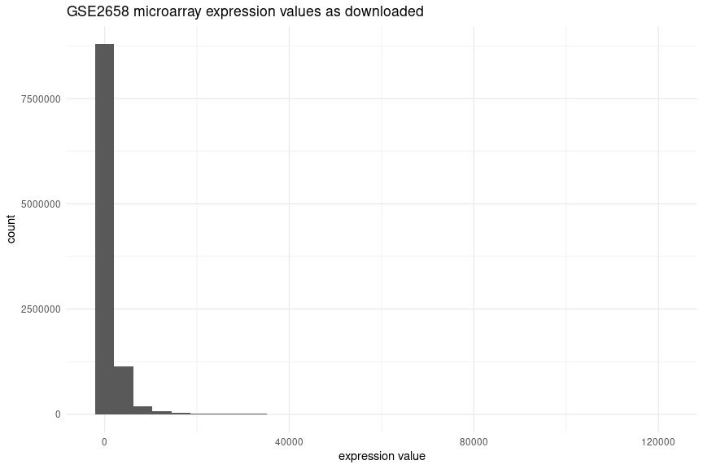

```r
ggplot(gse2658_exprs_sm_wgn_long) +
  geom_histogram(aes(expr)) + theme_minimal() +
  labs(x=("expression value"),
       title="GSE2658 microarray expression values as downloaded")
```

plot histogram of log2(raw expr values)

```
Warning: Removed 181 rows containing non-finite values (stat_bin).
```

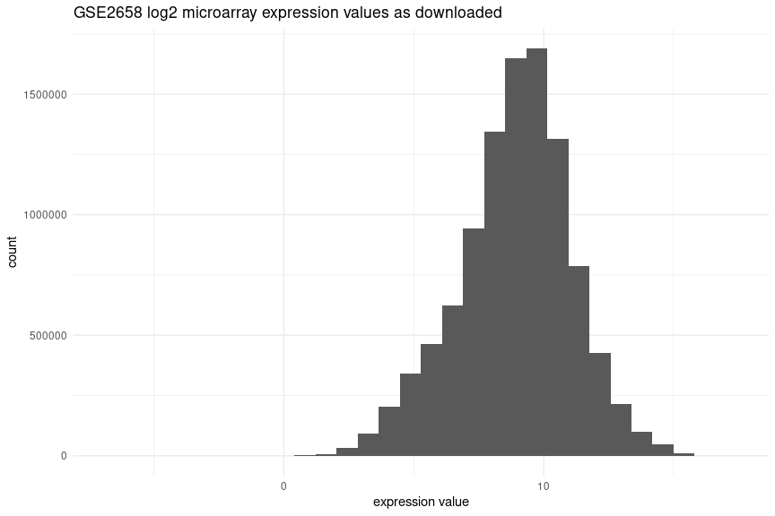

```r
ggplot(gse2658_exprs_sm_wgn_long) +
  geom_histogram(aes(log2(expr))) + theme_minimal() +
  labs(x=("expression value"),
       title="GSE2658 log2 microarray expression values as downloaded")
```

get gene length by gene_id

```r
gencode_gene_len <- gencode_annot %>% filter(feature=="exon") %>%
  mutate(ex_size=(end-start)+1) %>% group_by(gene_id) %>%
  dplyr::summarise(length = sum(ex_size))
```

*have to convert to gene_id* since the commpass loadings use gene_id and there is one gene name that has 2 IDs everything will get messed up unless I convert to gene_id now.

gene name `PAGR1` has 2 ensembl IDs: `ENSG00000185928` and `ENSG00000263136` in the CoMMpass data, but those 2 have been merged in newest ensembl.  
I need to try to map these probes to one, the other, or both…

```r
gse2658_features %>% filter(grepl("PAGR1", `Gene Symbol`)) %>% select(ID, GB_ACC, `Gene Symbol`)
```

|  | ID | GB_ACC | Gene Symbol |
| --- | --- | --- | --- |
| 1559125_at | 1559125_at | BC029255 | PAGR1 |
| 218300_at | 218300_at | NM_024516 | PAGR1 |
| 231878_at | 231878_at | AK026112 | PAGR1 |

`1559125_at` actually misses the gene in the newest ensembl and the GB_ACC is unhelpful

how different are the probes in expression?

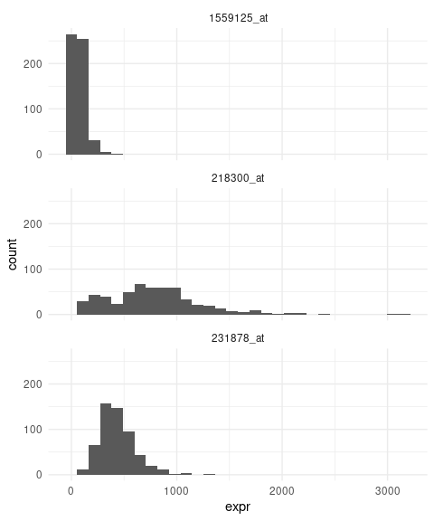

```r
gse2658_exprs_sm_wgn_long %>%
  filter(gene_name=="PAGR1") %>%
  ggplot() + geom_histogram(aes(expr)) + facet_wrap("probe_ID", ncol=1) + theme_minimal()
```

PAGR1 gene id garbage

Probeset: 218300_at Chromosome 16: 29,819,557-29,819,872  
in ENSE00003711437 of ENST00000320330.8 from gene ENSG00000185928  
in ENSE00001241136 of ENST00000609618.2 from gene ENSG00000263136

Probeset: 231878_at Chromosome 16: 29,822,107-29,822,455  
in ENSE00003711437 of ENST00000320330.8 from gene ENSG00000185928

Gene: ENSG00000185928  
ENST00000320330.8 PAGR1-201 Chromosome 16: 29,816,152-29,822,489 forward strand.  
ENST00000562285.1 Chromosome 16: 29,817,239-29,830,627 forward strand.

Gene: ENSG00000263136  
ENST00000609618.2 Chromosome 16: 29,812,261-29,820,092 forward strand.

**Plan:**  
1559125_at: remove  
218300_at: ENSG00000263136  
231878_at: ENSG00000185928

```r
gse2658_exprs_sm_long_gid <-
  left_join(gse2658_exprs_sm_wgn_long %>% filter(probe_ID!="1559125_at"), # remove 1559125_at
            gid_names %>% filter(gene_id %in% cmps_spec_rm$gene_id & gene_name!="PAGR1"), # join back in gene_ids except PAGR1
            by="gene_name") %>%
  mutate(gene_id=case_when(gene_name=="PAGR1" & probe_ID=="218300_at" ~ "ENSG00000263136",
                           gene_name=="PAGR1" & probe_ID=="231878_at" ~ "ENSG00000185928",
                           TRUE ~ gene_id)) %>%
  relocate(gene_id)
```

*now back to our regularly scheduled program* of normalizing the expression values, now by gene_id

```r
gse2658_exprs_sm_gid_sum <- gse2658_exprs_sm_long_gid %>%
  group_by(gene_id, sample_id) %>%
  summarise(gene_expr=sum(expr))
head(gse2658_exprs_sm_gid_sum, 10)
```

| gene_id | sample_id | gene_expr |
| --- | --- | --- |
| ENSG00000000419 | GSM102606 | 7510.6 |
| ENSG00000000419 | GSM102607 | 5238.3 |
| ENSG00000000419 | GSM102609 | 5572.0 |
| ENSG00000000419 | GSM102610 | 3834.4 |
| ENSG00000000419 | GSM102611 | 4012.9 |
| ENSG00000000419 | GSM102612 | 3970.1 |
| ENSG00000000419 | GSM102613 | 4203.8 |
| ENSG00000000419 | GSM102614 | 3476.8 |
| ENSG00000000419 | GSM102615 | 4353.5 |
| ENSG00000000419 | GSM102616 | 3341.4 |

2nd way to do the sum, just in case I messed up (though I think it’s ok the way I did it)

```r
gse2658_exprs_sm_gid_sum2 <-
  left_join(gse2658_exprs_sm_long_gid, gencode_gene_len, by="gene_id") %>%
  group_by(gene_id, sample_id) %>%
  mutate(cpk=expr/(length/1000)) %>%
  summarise(gene_expr=sum(cpk))
head(gse2658_exprs_sm_gid_sum2, 10)
```

| gene_id | sample_id | gene_expr |
| --- | --- | --- |
| ENSG00000000419 | GSM102606 | 1100.7768 |
| ENSG00000000419 | GSM102607 | 767.7414 |
| ENSG00000000419 | GSM102609 | 816.6496 |
| ENSG00000000419 | GSM102610 | 561.9815 |
| ENSG00000000419 | GSM102611 | 588.1430 |
| ENSG00000000419 | GSM102612 | 581.8702 |
| ENSG00000000419 | GSM102613 | 616.1219 |
| ENSG00000000419 | GSM102614 | 509.5706 |
| ENSG00000000419 | GSM102615 | 638.0624 |
| ENSG00000000419 | GSM102616 | 489.7259 |

```r
gse2658_exprs_sm_wgn_sum_wgl <- left_join(gse2658_exprs_sm_gid_sum, gencode_gene_len, by="gene_id")
head(gse2658_exprs_sm_wgn_sum_wgl, 10)
```

| gene_id | sample_id | gene_expr | length |
| --- | --- | --- | --- |
| ENSG00000000419 | GSM102606 | 7510.6 | 6823 |
| ENSG00000000419 | GSM102607 | 5238.3 | 6823 |
| ENSG00000000419 | GSM102609 | 5572.0 | 6823 |
| ENSG00000000419 | GSM102610 | 3834.4 | 6823 |
| ENSG00000000419 | GSM102611 | 4012.9 | 6823 |
| ENSG00000000419 | GSM102612 | 3970.1 | 6823 |
| ENSG00000000419 | GSM102613 | 4203.8 | 6823 |
| ENSG00000000419 | GSM102614 | 3476.8 | 6823 |
| ENSG00000000419 | GSM102615 | 4353.5 | 6823 |
| ENSG00000000419 | GSM102616 | 3341.4 | 6823 |

```r
gse2658_exprs_sm_wgn_sum_wgl <- gse2658_exprs_sm_wgn_sum_wgl %>% mutate(cpk=gene_expr/length)
head(gse2658_exprs_sm_wgn_sum_wgl,10)
```

| gene_id | sample_id | gene_expr | length | cpk |
| --- | --- | --- | --- | --- |
| ENSG00000000419 | GSM102606 | 7510.6 | 6823 | 1.1007768 |
| ENSG00000000419 | GSM102607 | 5238.3 | 6823 | 0.7677414 |
| ENSG00000000419 | GSM102609 | 5572.0 | 6823 | 0.8166496 |
| ENSG00000000419 | GSM102610 | 3834.4 | 6823 | 0.5619815 |
| ENSG00000000419 | GSM102611 | 4012.9 | 6823 | 0.5881430 |
| ENSG00000000419 | GSM102612 | 3970.1 | 6823 | 0.5818702 |
| ENSG00000000419 | GSM102613 | 4203.8 | 6823 | 0.6161219 |
| ENSG00000000419 | GSM102614 | 3476.8 | 6823 | 0.5095706 |
| ENSG00000000419 | GSM102615 | 4353.5 | 6823 | 0.6380624 |
| ENSG00000000419 | GSM102616 | 3341.4 | 6823 | 0.4897259 |

plot histogram of log2(cpk)

```
Warning: Removed 181 rows containing non-finite values (stat_bin).
```

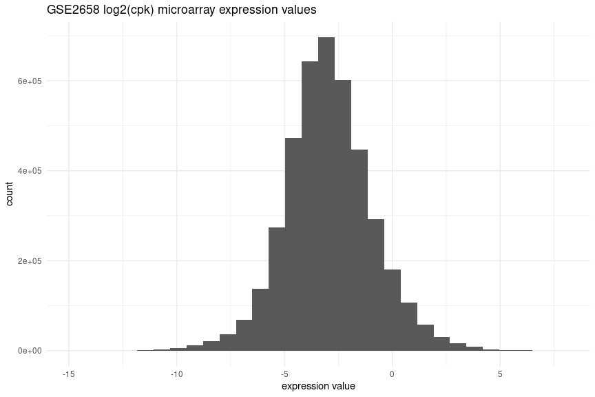

```r
ggplot(gse2658_exprs_sm_wgn_sum_wgl) +
  geom_histogram(aes(log2(cpk))) + theme_minimal() +
  labs(x=("expression value"),
       title="GSE2658 log2(cpk) microarray expression values")
```

```r
gse2658_exprs_szfctrs <- gse2658_exprs_sm_wgn_sum_wgl %>% ungroup() %>% group_by(sample_id) %>% summarise(szfctr=median(cpk, na.rm = T))
```

write out size factors for later use (like for normalizaing genes for UAMS or SBUK)

```r
# write_csv(gse2658_exprs_szfctrs, "gse2658_sample_size_factors.csv")
```

```r
gse2658_exprs_sm_wgn_sum_wgl_sz <- left_join(gse2658_exprs_sm_wgn_sum_wgl, gse2658_exprs_szfctrs, by="sample_id")
```

```r
gse2658_exprs_adj <- gse2658_exprs_sm_wgn_sum_wgl_sz %>%
  mutate(adjlogcpkmed=log2(cpk/szfctr))
```

plot histogram of adjlogcpkmed

```
Warning: Removed 181 rows containing non-finite values (stat_bin).
```

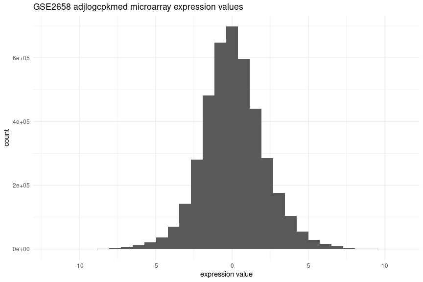

```r
ggplot(gse2658_exprs_adj) +
  geom_histogram(aes(adjlogcpkmed)) + theme_minimal() +
  labs(x=("expression value"),
       title="GSE2658 adjlogcpkmed microarray expression values")
```

2nd way continued…

```r
gse2658_exprs_szfctrs2 <- gse2658_exprs_sm_gid_sum2 %>% ungroup() %>%
  group_by(sample_id) %>%
  summarise(szfctr=median(gene_expr, na.rm = T))
```

```r
gse2658_exprs_sm_wgn_sum2_sz <- left_join(gse2658_exprs_sm_gid_sum2, gse2658_exprs_szfctrs2,
                                          by="sample_id")
```

```r
gse2658_exprs_adj2 <- gse2658_exprs_sm_wgn_sum2_sz %>%
  mutate(adjlogcpkmed=log2(gene_expr/szfctr))
```

both ways to do sum for CPK are the same, but this plot takes a long time to render…

```r
# plot(gse2658_exprs_adj$adjlogcpkmed, gse2658_exprs_adj2$adjlogcpkmed)
```

using original way

```r
dim(gse2658_exprs_adj)
```

```
[1] 4118153       7
```

## NAs and missing genes

deal with NA values for SCARB1 here,  
as well as putting in the TCGA gene_center values for the missing genes

```r
genes_still_mis <- cmps_spec_rm %>%
  filter(!gene_id %in% gse2658_exprs_adj$gene_id) %>%
  pull(gene_id)
```

```r
# write_csv(data.frame(gene_id=genes_still_mis), "genes_missing_GSE2658_from_commpass_20220414.csv")
```

gene means for values to fill in

```r
gene_means <- left_join(cmps_spec_rm, gid_names, by="gene_id") %>%
    select(gene_id, mean)
```

get things in order just to be sure

```r
gse2658_exprs_adj <- gse2658_exprs_adj %>% arrange(gene_id, sample_id)
```

```r
gse2658_sids <- unique(gse2658_exprs_adj$sample_id)
```

put in genes that are missing from the microarray data  
use mean value for that gene from the CoMMpass loadings matrix

```r
# makes empty DF for adding the genes
results <- data.frame()
for(g in genes_still_mis){
  results <- bind_rows(results, data.frame(gene_id=rep(g,559), sample_id=gse2658_sids))
}
# joins on the mean values and makes them the adjlogcpkmed
results <- left_join(results, gene_means, by = "gene_id") %>%
  rename(adjlogcpkmed=mean)
```

put it all back together

```r
gse2658_exprs_adj_cmplt <-
  bind_rows(gse2658_exprs_adj %>% select(gene_id, sample_id, adjlogcpkmed),
            results)
head(gse2658_exprs_adj_cmplt, 10)
```

[output not shown]

```r
tail(gse2658_exprs_adj_cmplt, 10)
```

| gene_id | sample_id | adjlogcpkmed |
| --- | --- | --- |
| ENSG00000272916 | GSM95817 | -3.170116 |
| ENSG00000272916 | GSM95818 | -3.170116 |
| ENSG00000272916 | GSM95819 | -3.170116 |
| ENSG00000272916 | GSM95820 | -3.170116 |
| ENSG00000272916 | GSM95821 | -3.170116 |
| ENSG00000272916 | GSM95822 | -3.170116 |
| ENSG00000272916 | GSM95823 | -3.170116 |
| ENSG00000272916 | GSM95824 | -3.170116 |
| ENSG00000272916 | GSM95825 | -3.170116 |
| ENSG00000272916 | GSM95826 | -3.170116 |

still need to deal with NAs

```r
gse2658_exprs_adj_cmplt %>% filter(if_any(everything(), is.na))
```

| gene_id | sample_id | adjlogcpkmed |
| --- | --- | --- |
| ENSG00000073060 | GSM95646 | NA |
| ENSG00000073060 | GSM95647 | NA |
| ENSG00000073060 | GSM95648 | NA |
| ENSG00000073060 | GSM95649 | NA |
| ENSG00000073060 | GSM95650 | NA |
| ENSG00000073060 | GSM95651 | NA |
| ENSG00000073060 | GSM95652 | NA |
| ENSG00000073060 | GSM95653 | NA |
| ENSG00000073060 | GSM95654 | NA |
| ENSG00000073060 | GSM95655 | NA |

[output cut: 171 more lines]

replace NAs in `SCARB1` gene (`ENSG00000073060`) with mean value from loadings matrix

```r
gse2658_exprs_adj_cmplt <- left_join(gse2658_exprs_adj_cmplt, gene_means, by = "gene_id") %>%
  mutate(adjlogcpkmed=coalesce(adjlogcpkmed, mean)) %>%
  select(-mean)
gse2658_exprs_adj_cmplt %>% filter(gene_id=="ENSG00000073060")
```

| gene_id | sample_id | adjlogcpkmed |
| --- | --- | --- |
| ENSG00000073060 | GSM102606 | -0.987007909 |
| ENSG00000073060 | GSM102607 | -1.259564289 |
| ENSG00000073060 | GSM102609 | -1.920778143 |
| ENSG00000073060 | GSM102610 | -2.750313297 |
| ENSG00000073060 | GSM102611 | -1.794780472 |
| ENSG00000073060 | GSM102612 | -2.569471477 |
| ENSG00000073060 | GSM102613 | -1.774573134 |
| ENSG00000073060 | GSM102614 | -1.250720197 |
| ENSG00000073060 | GSM102615 | -2.683223483 |
| ENSG00000073060 | GSM102616 | -2.437424118 |

[output cut: 549 more lines]

plot histogram of adjlogcpkmed from final version (with missing genes and NAs corrected)

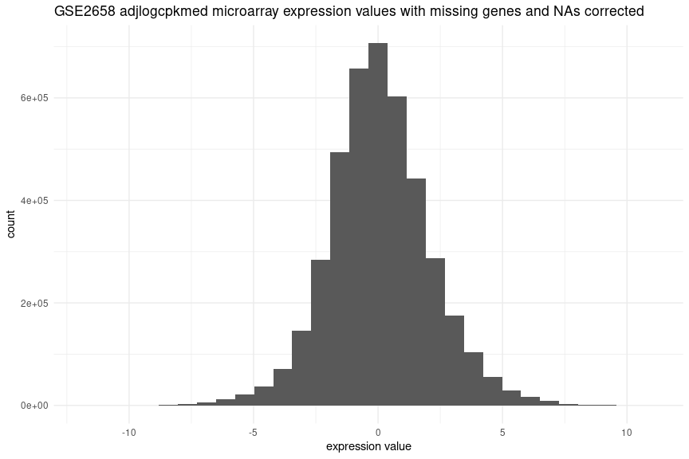

```r
ggplot(gse2658_exprs_adj_cmplt) +
  geom_histogram(aes(adjlogcpkmed)) + theme_minimal() +
  labs(x=("expression value"),
       title="GSE2658 adjlogcpkmed microarray expression values with missing genes and NAs corrected")
```

final version (with missing genes and NAs corrected) with gene_ids

```r
# write_csv(gse2658_exprs_adj_cmplt, "gse2658_exprs_adj_20220503.csv")
```

## normalization equation

$$e_g=log_2 \left (\frac{cpk}{size factor}\right)$$

$$cpk=\frac{ \sum_{s=1}^{m}c_s }{gene \, length_{kb}}$$

$$size \, factor= median(sample \, cpk)$$

## phenotype data

column structure is weird

```r
colnames(gse2658_pdata)
```

```
 [1] "title"                   "geo_accession"           "status"                  "submission_date"
 [5] "last_update_date"        "type"                    "channel_count"           "source_name_ch1"
 [9] "organism_ch1"            "characteristics_ch1"     "characteristics_ch1.1"   "characteristics_ch1.2"
[13] "characteristics_ch1.3"   "characteristics_ch1.4"   "characteristics_ch1.5"   "characteristics_ch1.6"
[17] "characteristics_ch1.7"   "characteristics_ch1.8"   "characteristics_ch1.9"   "characteristics_ch1.10"
[21] "characteristics_ch1.11"  "molecule_ch1"            "extract_protocol_ch1"    "label_ch1"
[25] "label_protocol_ch1"      "taxid_ch1"               "hyb_protocol"            "scan_protocol"
[29] "description"             "description.1"           "description.2"           "description.3"
[33] "description.4"           "description.5"           "data_processing"         "data_processing.1"
[37] "data_processing.2"       "data_processing.3"       "platform_id"             "contact_name"
[41] "contact_email"           "contact_phone"           "contact_laboratory"      "contact_department"
[45] "contact_institute"       "contact_address"         "contact_city"            "contact_state"
[49] "contact_zip/postal_code" "contact_country"         "supplementary_file"      "data_row_count"
```

### important variables for me now:

ID that matches expression data: `geo_accession`

```r
head(gse2658_pdata$geo_accession)
```

```
[1] "GSM50986" "GSM50987" "GSM50988" "GSM50989" "GSM50990" "GSM50991"
```

treatment info: `source_name_ch1`  
looks like all samples are pre-treatment? doesn’t really jive with what’s in the paper, but…

```r
table(gse2658_pdata$source_name_ch1, useNA="a")
```

```
pre-treatment bone marrow                      <NA>
                      559                         0
```

survival indicator: `characteristics_ch1`  
info `(Indicator of disease-related death; integer, 0=alive or death by other cause, 1=disease related death, na=death cause undetermined)`  
will need to extract the 1/0 version

```r
head(gse2658_pdata$characteristics_ch1)
```

```
[1] "[SURIND=0 (Indicator of disease-related death; integer, 0=alive or death by other cause, 1=disease related death, na=death cause undetermined)]"
[2] "[SURIND=0 (Indicator of disease-related death; integer, 0=alive or death by other cause, 1=disease related death, na=death cause undetermined)]"
[3] "[SURIND=0 (Indicator of disease-related death; integer, 0=alive or death by other cause, 1=disease related death, na=death cause undetermined)]"
[4] "[SURIND=0 (Indicator of disease-related death; integer, 0=alive or death by other cause, 1=disease related death, na=death cause undetermined)]"
[5] "[SURIND=1 (Indicator of disease-related death; integer, 0=alive or death by other cause, 1=disease related death, na=death cause undetermined)]"
[6] "[SURIND=0 (Indicator of disease-related death; integer, 0=alive or death by other cause, 1=disease related death, na=death cause undetermined)]"
```

survival indicator: `characteristics_ch1.2`  
info: `(Follow-up time in months from Pre-Treatment baseline; integer)`  
will have to extract `SURTIM` to get the value in months

```r
head(gse2658_pdata$characteristics_ch1.2)
```

```
[1] "[SURTIM=69.24 (Follow-up time in months from Pre-Treatment baseline; integer)]"
[2] "[SURTIM=66.67 (Follow-up time in months from Pre-Treatment baseline; integer)]"
[3] "[SURTIM=66.43 (Follow-up time in months from Pre-Treatment baseline; integer)]"
[4] "[SURTIM=66.5 (Follow-up time in months from Pre-Treatment baseline; integer)]"
[5] "[SURTIM=42.67 (Follow-up time in months from Pre-Treatment baseline; integer)]"
[6] "[SURTIM=65 (Follow-up time in months from Pre-Treatment baseline; integer)]"
```

making survival dataframe:

```r
gse2658_survd <- gse2658_pdata %>%
  select(sample_id=geo_accession, characteristics_ch1, characteristics_ch1.2)
gse2658_survd$censos <- str_match(gse2658_survd$characteristics_ch1, pattern="\\[SURIND=(.?)\\s")[,2]
gse2658_survd$ttcos <- str_match(gse2658_survd$characteristics_ch1.2, pattern="\\[SURTIM=(.?)\\s")[,2]
```

```r
gse2658_survd <- gse2658_pdata %>%
  select(sample_id=geo_accession, characteristics_ch1, characteristics_ch1.2) %>%
  mutate(censos=as.numeric(str_match(characteristics_ch1, pattern="\\[SURIND=(.?)\\s")[,2])) %>%
  mutate(ttcos=gsub("\\[SURTIM=","", characteristics_ch1.2)) %>%
  mutate(ttcos=as.numeric(gsub("\\s*\\(Follow-up time in months from Pre-Treatment baseline; integer)]\\s*","", ttcos))) %>%
  tibble::remove_rownames()
gse2658_survd
```

| sample_id | characteristics_ch1 | characteristics_ch1.2 | censos | ttcos |
| --- | --- | --- | --- | --- |
| GSM50986 | [SURIND=0 (Indicator of disease-related death; integer, 0=alive or death by other cause, 1=disease related death, na=death cause undetermined)] | [SURTIM=69.24 (Follow-up time in months from Pre-Treatment baseline; integer)] | 0 | 69.24 |
| GSM50987 | [SURIND=0 (Indicator of disease-related death; integer, 0=alive or death by other cause, 1=disease related death, na=death cause undetermined)] | [SURTIM=66.67 (Follow-up time in months from Pre-Treatment baseline; integer)] | 0 | 66.67 |
| GSM50988 | [SURIND=0 (Indicator of disease-related death; integer, 0=alive or death by other cause, 1=disease related death, na=death cause undetermined)] | [SURTIM=66.43 (Follow-up time in months from Pre-Treatment baseline; integer)] | 0 | 66.43 |
| GSM50989 | [SURIND=0 (Indicator of disease-related death; integer, 0=alive or death by other cause, 1=disease related death, na=death cause undetermined)] | [SURTIM=66.5 (Follow-up time in months from Pre-Treatment baseline; integer)] | 0 | 66.50 |
| GSM50990 | [SURIND=1 (Indicator of disease-related death; integer, 0=alive or death by other cause, 1=disease related death, na=death cause undetermined)] | [SURTIM=42.67 (Follow-up time in months from Pre-Treatment baseline; integer)] | 1 | 42.67 |
| GSM50991 | [SURIND=0 (Indicator of disease-related death; integer, 0=alive or death by other cause, 1=disease related death, na=death cause undetermined)] | [SURTIM=65 (Follow-up time in months from Pre-Treatment baseline; integer)] | 0 | 65.00 |
| GSM50992 | [SURIND=0 (Indicator of disease-related death; integer, 0=alive or death by other cause, 1=disease related death, na=death cause undetermined)] | [SURTIM=65.2 (Follow-up time in months from Pre-Treatment baseline; integer)] | 0 | 65.20 |
| GSM50993 | [SURIND=1 (Indicator of disease-related death; integer, 0=alive or death by other cause, 1=disease related death, na=death cause undetermined)] | [SURTIM=38.27 (Follow-up time in months from Pre-Treatment baseline; integer)] | 1 | 38.27 |
| GSM50994 | [SURIND=0 (Indicator of disease-related death; integer, 0=alive or death by other cause, 1=disease related death, na=death cause undetermined)] | [SURTIM=64.73 (Follow-up time in months from Pre-Treatment baseline; integer)] | 0 | 64.73 |
| GSM50995 | [SURIND=0 (Indicator of disease-related death; integer, 0=alive or death by other cause, 1=disease related death, na=death cause undetermined)] | [SURTIM=64.33 (Follow-up time in months from Pre-Treatment baseline; integer)] | 0 | 64.33 |

[output cut: 549 more lines]

```r
set.seed(4831)
gse2658_survd_test <- gse2658_survd %>%
  slice_sample(n=20) %>%
  select(sample_id, censos, ttcos)
gse2658_survd_test %>% arrange(sample_id)
```

| sample_id | censos | ttcos |
| --- | --- | --- |
| GSM50996 | 0 | 64.33 |
| GSM51007 | 0 | 61.33 |
| GSM51014 | 0 | 59.38 |
| GSM51030 | 0 | 57.15 |
| GSM51038 | 0 | 59.70 |
| GSM51059 | 0 | 54.57 |
| GSM51101 | 0 | 49.23 |
| GSM51103 | 0 | 49.55 |
| GSM51155 | 0 | 42.17 |
| GSM51190 | 1 | 11.41 |

[output cut: 10 more lines]

```r
gse2658_pdata %>%
  filter(geo_accession %in% gse2658_survd_test$sample_id) %>%
  select(geo_accession, characteristics_ch1, characteristics_ch1.2) %>%
  arrange(geo_accession)
```

|  | geo_accession | characteristics_ch1 | characteristics_ch1.2 |
| --- | --- | --- | --- |
| GSM50996 | GSM50996 | [SURIND=0 (Indicator of disease-related death; integer, 0=alive or death by other cause, 1=disease related death, na=death cause undetermined)] | [SURTIM=64.33 (Follow-up time in months from Pre-Treatment baseline; integer)] |
| GSM51007 | GSM51007 | [SURIND=0 (Indicator of disease-related death; integer, 0=alive or death by other cause, 1=disease related death, na=death cause undetermined)] | [SURTIM=61.33 (Follow-up time in months from Pre-Treatment baseline; integer)] |
| GSM51014 | GSM51014 | [SURIND=0 (Indicator of disease-related death; integer, 0=alive or death by other cause, 1=disease related death, na=death cause undetermined)] | [SURTIM=59.38 (Follow-up time in months from Pre-Treatment baseline; integer)] |
| GSM51030 | GSM51030 | [SURIND=0 (Indicator of disease-related death; integer, 0=alive or death by other cause, 1=disease related death, na=death cause undetermined)] | [SURTIM=57.15 (Follow-up time in months from Pre-Treatment baseline; integer)] |
| GSM51038 | GSM51038 | [SURIND=0 (Indicator of disease-related death; integer, 0=alive or death by other cause, 1=disease related death, na=death cause undetermined)] | [SURTIM=59.7 (Follow-up time in months from Pre-Treatment baseline; integer)] |
| GSM51059 | GSM51059 | [SURIND=0 (Indicator of disease-related death; integer, 0=alive or death by other cause, 1=disease related death, na=death cause undetermined)] | [SURTIM=54.57 (Follow-up time in months from Pre-Treatment baseline; integer)] |
| GSM51101 | GSM51101 | [SURIND=0 (Indicator of disease-related death; integer, 0=alive or death by other cause, 1=disease related death, na=death cause undetermined)] | [SURTIM=49.23 (Follow-up time in months from Pre-Treatment baseline; integer)] |
| GSM51103 | GSM51103 | [SURIND=0 (Indicator of disease-related death; integer, 0=alive or death by other cause, 1=disease related death, na=death cause undetermined)] | [SURTIM=49.55 (Follow-up time in months from Pre-Treatment baseline; integer)] |
| GSM51155 | GSM51155 | [SURIND=0 (Indicator of disease-related death; integer, 0=alive or death by other cause, 1=disease related death, na=death cause undetermined)] | [SURTIM=42.17 (Follow-up time in months from Pre-Treatment baseline; integer)] |
| GSM51190 | GSM51190 | [SURIND=1 (Indicator of disease-related death; integer, 0=alive or death by other cause, 1=disease related death, na=death cause undetermined)] | [SURTIM=11.41 (Follow-up time in months from Pre-Treatment baseline; integer)] |

[output cut: 10 more lines]

seems legit.

join survival data with expression data

```r
gse2658_exprs_survd <- left_join(gse2658_exprs_adj_cmplt,
          gse2658_survd %>% select(sample_id, censos, ttcos),
          by="sample_id")
```

write out version with CoMMpass means in for missing genes

```r
# write_csv(gse2658_exprs_survd, "gse2658_adj_expression_survival_data_20220505.csv")
```

## version with zeros

also need a version with zeros for expression values  
will use it to center on GSE2658 data (instead of CoMMpass data)

`gse2658_exprs_adj` is the adjusted expression but before adding in mean values from CoMMpass

[output not shown]

genes:

```r
gse2658_exprs_adj %>% distinct(gene_id) %>% dim()
```

```
[1] 7367    1
```

makes sense 7449-82=7367

```r
gse2658_exprs_adj %>% ungroup() %>% distinct(sample_id) %>% dim()
```

```
[1] 559   1
```

OK

put it all back together

```r
gse2658_exprs_adj_wzeros <-
  bind_rows(gse2658_exprs_adj %>% select(gene_id, sample_id, adjlogcpkmed),
            results_wz)
head(gse2658_exprs_adj_wzeros, 10)
```

| gene_id | sample_id | adjlogcpkmed |
| --- | --- | --- |
| ENSG00000000419 | GSM102606 | 3.083196 |
| ENSG00000000419 | GSM102607 | 2.567279 |
| ENSG00000000419 | GSM102609 | 2.671092 |
| ENSG00000000419 | GSM102610 | 2.116283 |
| ENSG00000000419 | GSM102611 | 2.163607 |
| ENSG00000000419 | GSM102612 | 2.191636 |
| ENSG00000000419 | GSM102613 | 2.227074 |
| ENSG00000000419 | GSM102614 | 2.006474 |
| ENSG00000000419 | GSM102615 | 2.209241 |
| ENSG00000000419 | GSM102616 | 1.916885 |

still need to deal with NAs

[output not shown]

[output cut: 171 more lines]

replace NAs in `SCARB1` gene (`ENSG00000073060`) with zero

```r
gse2658_exprs_adj_wzeros <- gse2658_exprs_adj_wzeros %>% replace_na(replace=list(adjlogcpkmed=0))
gse2658_exprs_adj_wzeros %>% filter(gene_id=="ENSG00000073060")
```

| gene_id | sample_id | adjlogcpkmed |
| --- | --- | --- |
| ENSG00000073060 | GSM102606 | -0.987007909 |
| ENSG00000073060 | GSM102607 | -1.259564289 |
| ENSG00000073060 | GSM102609 | -1.920778143 |
| ENSG00000073060 | GSM102610 | -2.750313297 |
| ENSG00000073060 | GSM102611 | -1.794780472 |
| ENSG00000073060 | GSM102612 | -2.569471477 |
| ENSG00000073060 | GSM102613 | -1.774573134 |
| ENSG00000073060 | GSM102614 | -1.250720197 |
| ENSG00000073060 | GSM102615 | -2.683223483 |
| ENSG00000073060 | GSM102616 | -2.437424118 |

[output cut: 549 more lines]

plot histogram of adjlogcpkmed from final version (with missing genes and NAs corrected)

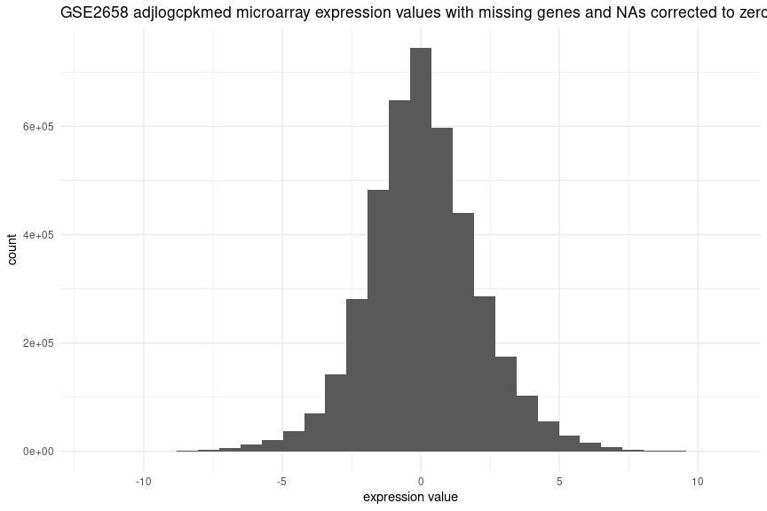

```r
ggplot(gse2658_exprs_adj_wzeros) +
  geom_histogram(aes(adjlogcpkmed)) + theme_minimal() +
  labs(x=("expression value"),
       title="GSE2658 adjlogcpkmed microarray expression values with missing genes and NAs corrected to zero")
```

final version (with missing genes and NAs corrected) with gene_ids

join survival data with expression data

```r
gse2658_exprs_wzeros_survd <- left_join(gse2658_exprs_adj_wzeros,
          gse2658_survd %>% select(sample_id, censos, ttcos),
          by="sample_id")
```

final version (with missing genes and NAs corrected) with gene_ids and survival data